# Stressor 2018: Shipping

Compiled on Thu Apr 12 12:10:19 2018 by frazier

# Summary

We combine two data sources for this analysis.

Yearly shipping data from Tournadre is used to create yearly rasters describing the proportional change in shipping relative to 2011 (which corresponds to the year with the bulk of our shipping data).

We the multiple each raster describing the proportional change in shipping with the shipping layer used in the previous cumulative human impacts project (Halpern et al. 2015). We only use the Tournadre data to derive the correction factor because the data has relatively low resolution and is stochastic.

By doing this, we have the best of both worlds: high resolution temporal shipping data.

# Data Source

Tournadre, J. 2018. The ship database version-2. DOI10.13140/RG.2.2.15947.08480 (https://www.researchgate.net/publication/322520264_The_ship_database_version-2)

**Downloaded**: Feb 1 2018

**Description**: Yearly ship density data. Data is not based on AIS data, but rather: > In a recent study, Tournadre [2007] demonstrated that any target emerging from the sea could have a detectable signature in the noise part (i.e., the portion of the echo waveform above the sea) of high resolution satellite altimeter waveforms.

**Native data resolution**: 1 x 2 degree

**Time range**: 1992-2016

**Format**: Netcdf

**Units**: ships per cell, represents all the ships expected to be at sea, e.g., 62,000 in 2009

**Notes about the data**: We used the smoothed version of the data

*Cumulative Human Impacts data*

**Reference**: Walbridge, S. 2013. Assessing ship movements using volunteered geographic information. Thesis, University of California, Santa Barbara. https://www.4326.us/thesis/walbridge-masters-thesis.pdf

Halpern et al. 2015. Spatial and temporal changes in cumulative human impacts on the world’s ocean. Nature Cummunications 6, 7615. doi:10.1038/ncomms8615

**Description**: Shipping data created by Sean Walbridge

**Native data resolution**: ~1 km

**Time range**: One raster data that was created using data from 1991-2011, but most of the data is from 2011.

**Format**: raster, .tif

# Methods

```r
#set options for all chunks in code
knitr::opts_chunk$set(warning=FALSE, message=FALSE,fig.width=6, fig.height=6)

#libraries
library(raster)
library(ncdf4)
library(maps)
library(RColorBrewer)
library(sf)
library(dplyr)
library(doParallel)
library(foreach)
library(parallel)

source("https://raw.githubusercontent.com/OHI-Science/ohiprep_v2018/master/src/R/spatial_common.R")
cols = rev(colorRampPalette(brewer.pal(11, 'Spectral'))(255)) # rainbow color scheme

# setwd("stressors/shipping")

# parallel processing
cl<-makeCluster(10)
registerDoParallel(cl)
```

## Shipping density data

These data are used to determine the proportional change in shipping (relative to 2011) across years. Each year’s density raster is divided by the reference density raster (2011). The 2011 year was chosen because most of the data in the original shipping data was from 2011.

Exploring the yearly shipping density data.

```r
ncin <- nc_open(file.path(dir_M, "git-annex/impact_acceleration/stressors/shipping/prod_gridded_1992-2017.nc"))
#ncin <- nc_open(file.path(dir_M, "git-annex/impact_acceleration/stressors/shipping/ships.nc"))
print(ncin)
attributes(ncin$var)$names
nc_close(ncin)
```

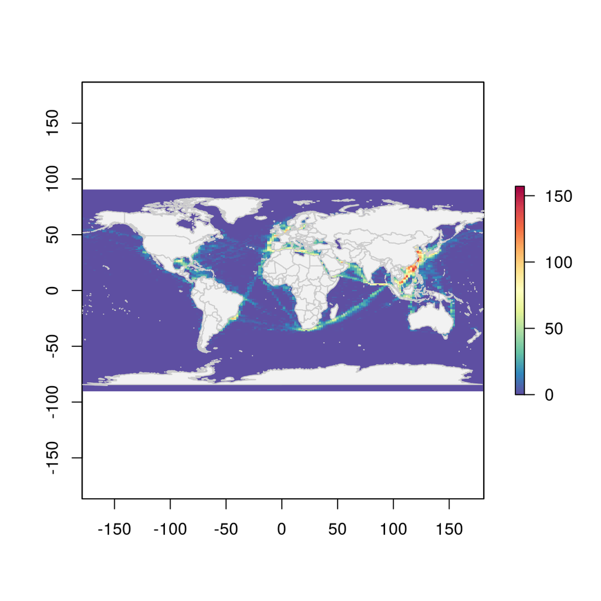

```r
## get the data and create a raster stack
raw <- stack(file.path(dir_M, "git-annex/impact_acceleration/stressors/shipping/prod_gridded_1992-2017.nc"),
             varname="nships_smoothed") #nships_smoothed

plot_data <- rotate(flip(flip(t((raw[[25]])), direction = 'y'), direction = 'x'))
plot(plot_data, col=cols)
#click(tmp)
maps::map('world', col='gray95', fill=T, border='gray80', add=T)
```

```r
# data standardized to 62,000 ships in 2009
# cellStats(raw[[18]], stat='sum')
# I get exactly 62,000 (using non-smoothed data)!
```

Extracting the Netcdf data and saving as individual rasters.

```r
raw <- stack(file.path(dir_M, "git-annex/impact_acceleration/stressors/shipping/prod_gridded_1992-2017.nc"),
             varname="nships_smoothed") #nships_smoothed

# convert names to year (equal to days since 1992)
names(raw) <- round(as.numeric(sub("X", "", names(raw)))/365.2422)

## convert 0 values to NA (since not clear for each raster whether it is NA or zero)
for (year in 1994:2016){ #year = 2015
  rast_year <- grep(year, names(raw))
  tmp <- raw[[rast_year]]
  tmp <- rotate(flip(flip(t((tmp)), direction = 'y'), direction = 'x'))
  tmp[tmp==0] <- NA
  writeRaster(tmp, file.path(dir_M, sprintf("git-annex/impact_acceleration/stressors/shipping/int/shipping_raw_%s.tif", year)),
              overwrite=TRUE)
}

# tmp <- raster(file.path(dir_M, "git-annex/impact_acceleration/stressors/shipping/int/shipping_raw_2015.tif"))
# plot(tmp)
```

[output not shown]

```r
files <- list.files(file.path(dir_M, "git-annex/impact_acceleration/stressors/shipping/int"),
                    pattern = "raw", full = TRUE)

for (year in 1994:2016){ # year = 2015

  year_range <- paste(year:(year+2), collapse="|")

  names_years_3 <- grep(year_range, files, value = TRUE)
  years_3 <- stack(names_years_3)
  mean_narm = function(x,...){mean(x, na.rm=TRUE)}
  datasum<- calc(years_3, fun = mean_narm)
  #plot(datasum, col=cols)

  writeRaster(datasum,
      file.path(dir_M, sprintf("git-annex/impact_acceleration/stressors/shipping/int/shipping_3_yr_%s.tif", year)),
              overwrite=TRUE)
}
```

```r
files <- list.files(file.path(dir_M, "git-annex/impact_acceleration/stressors/shipping/int"),
                              pattern = "raw", full = TRUE)

ref_years <- grep("2009|2010|2011|2012|2013", files)
ref <- stack(files[ref_years]) #nships_smoothed

mean_narm = function(x,...){mean(x, na.rm=TRUE)}
ref_mean <- calc(ref, fun = mean_narm)
plot(ref_mean, col=cols)
click(ref_mean)

writeRaster(ref_mean, file.path(dir_M, "git-annex/impact_acceleration/stressors/shipping/int/reference_mean_2009_2013.tif"), overwrite=TRUE)
```

Divide each year’s density by the reference period.

There are many NA values, where clearly there would be data if there was less stochasticity in the data. I replaced these values with the overall proportional change in total shipping. For example,

NA values = sum(all raster cells in scenario year) / sum(all raster cells in reference year)

For example, for the 2016 data, the NAs get replaced with 1.17.

```r
# get total number of ships across all cells from the reference period.
ref_mean <- raster(file.path(dir_M, "git-annex/impact_acceleration/stressors/shipping/int/reference_mean_2009_2013.tif"))
ref_total_ships <- cellStats(ref_mean, stat='sum', na.rm=TRUE)

foreach(year = 1994:2016,.packages="dplyr") %dopar%{ # file_name = l[1]
#for(year in 1994:2016){ # year = 2016
  scen_rast <- raster::raster(file.path(dir_M, sprintf("git-annex/impact_acceleration/stressors/shipping/int/shipping_3_yr_%s.tif", year)))
  prop <- raster::overlay(scen_rast, ref_mean, fun=function(x,y)x/y)

  # determine total number of ships (used to estimate NA cells)
  vals <- raster::getValues(prop)
  scen_total_ships <- raster::cellStats(scen_rast, stat="sum", na.rm=TRUE)
  gapfill_val <- scen_total_ships/ref_total_ships

  # get to proper projection, etc.
  sp::proj4string(prop) <- sp::CRS("+init=epsg:4326")
  prop <- raster::shift(prop, x = -1)
  raster::projectRaster(prop, ocean, over=TRUE, method = "ngb",
                        filename = file.path(dir_M, sprintf("git-annex/impact_acceleration/stressors/shipping/int/prop_change_%s_mol_na.tif", year)), overwrite=TRUE)

  prop_mol <- raster::raster(file.path(dir_M, sprintf("git-annex/impact_acceleration/stressors/shipping/int/prop_change_%s_mol_na.tif", year)))

  # gapfill missing cells
  raster::reclassify(prop_mol, cbind(NA, NA, gapfill_val), right=FALSE, filename = file.path(dir_M, sprintf("git-annex/impact_acceleration/stressors/shipping/int/prop_change_%s_mol_gf.tif", year)), overwrite=TRUE)

  # tmp <- raster(file.path(dir_M, sprintf("git-annex/impact_acceleration/stressors/shipping/int/prop_change_%s_mol_gf.tif", year)))
  #  tmp_old <- raster(file.path(dir_M, "git-annex/impact_acceleration/stressors/shipping/int/prop_change_2016_mol.tif"))
  #  tmp_old
  #  tmp
  # plot(tmp_old)
  # plot(tmp)
  }

# delete extra files
tmp <- list.files(file.path(dir_M, "git-annex/impact_acceleration/stressors/shipping/int"),
                            pattern="mol_na.tif", full=TRUE)
file.remove(tmp)
```